# AGBRESA Spatial Cognition 1

A Stahn

10/27/2021

#Required Packages

```r
library(knitr) # for kable
library(readxl) # read xls
library(DT) # Print table nicely in markdown
library(reshape2) # wide to long
library(plyr) # ldply
library(tidyverse) # for fct_relevel

library(lme4) # for adding mixed model functions to plot
library(lmerTest) # for adding mixed model functions to plot
library(emmeans) # for adding mixed model marignal means and se to plot
library(qdapTools) # list_df2df(tbl_mm_fac_aov)

library(ggpubr) # for compare means, descriptives and theme_pubr
library(ggplot2)
library(ggsci)
library(scales)
library(cowplot) # for plot_grid, combine plots using cowplot
```

#Themes for Plots

```r
# Correct ggplot2 pts and fonts
ggplot_factor_line <- ggplot2::.pt*72.27/96
ggplot_factor_font = 1.0

# Create project report theme
theme_report_white  <-  theme_pubr() + theme(
  axis.line = element_line(size = 0.5 / ggplot_factor_line,color="black"),
  axis.ticks = element_line(size = 0.5 / ggplot_factor_line, color="black"),
  axis.ticks.length = unit(0.2, "cm"),
  text = element_text(size = 8 * ggplot_factor_font,
                      family="Helvetica",
                      colour="black"),
  axis.text.x=element_text(angle = 0,
                           vjust = 0.5,
                           size = 8 * ggplot_factor_font,
                           family = "Helvetica",
                           colour = "black"), #face="bold"
  axis.text.y = element_text(angle = 0,
                            vjust = 0.5,
                            size= 8 * ggplot_factor_font,
                            family = "Helvetica",
                            colour="black"),
  axis.title.x = element_text(angle = 0,
                            vjust = 0.5,
                            size= 8 * ggplot_factor_font,
                            family="Helvetica",
                            colour="black",
                            face="bold"),
  axis.title.y = element_text(angle = 90,
                            vjust = 0.5,
                            size= 8 * ggplot_factor_font,
                            family = "Helvetica",
                            colour = "black",
                            face = "bold") # face = "bold"
  )
```

#Load Data

```r
# Demographics
df_demo <- read_excel("./Data/Data Demographics.xlsx",sheet = "Data Demo")
df_demo[c(1:5)] <- lapply(df_demo[c(1:5)], as.factor)

# SUT
df_sut <- read_excel("./Data/Data Spatial Cognition 1.xlsx", sheet = "Data SUT z")
df_sut[c(1:3)] <- lapply(df_sut[c(1:3)], as.factor)

# PTO
df_pto <- read_excel("./Data/Data Spatial Cognition 1.xlsx", sheet = "Data PTO z")
df_pto[c(1:4)] <- lapply(df_pto[c(1:4)], as.factor)

# 4MTN
df_4mtn <- read_excel("./Data/Data Spatial Cognition 1.xlsx", sheet = "Data 4MTN z")
df_4mtn[c(1:2)] <- lapply(df_4mtn[c(1:2)], as.factor)
df_4mtn <- as.data.frame(df_4mtn)

# NAVIS 2D
df_navis_2d <- read_excel("./Data/Data Spatial Cognition 1.xlsx", sheet = "Data NAVIS 2D z")
df_navis_2d[c(1:3)] <- lapply(df_navis_2d[c(1:3)], as.factor)
```

#Functions Descritpive Stats

```r
# Function to check data completion
func_data_completion <- function(data, ...) {

  if(!"time.f" %in% names(data)) {
    data$time.f <- as.factor( c( rep(1, nrow(data) ) ) )
    }

  if(!"cond.f" %in% names(data)) {
    data$cond.f <- as.factor( c( rep(1, nrow(data) ) ) )
    }

  data <- reshape2::melt( data,
                              id.vars = names( Filter(is.factor, data) )
                              )  %>%

  group_by(variable) %>%
  dplyr::summarise(
      N = 24 * length( levels(time.f) ) * length( levels(cond.f) ),
      n = sum( !is.na(value) ),
      Percent = n / N * 100
      )
}

# Function to compute descriptives
func_desc <- function(data, ...) {
  df_tmp <- df_demo[ , !names(df_demo) %in% c("age","height", "weight")]
  data <- merge(df_tmp, data, by = "id") #add demo
  data <- reshape2::melt( data,
                              id.vars = names( Filter(is.factor, data) )
                              )
  groups <- enquos(...)

  result <- data %>%

    group_by(!!!groups) %>%

    dplyr::summarise(
      MEAN = mean(value, na.rm = T),
      SE = sd(value, na.rm = T) / sqrt(length(value) )
      )
  return(result)
}
```

#Functions Plotting

```r
# Wrapper function for line plots, forwards to func_plot_line_facet
func_plot_line <- function(x) {ggplot(x, tmpaes_plot) +
    theme_report_white +
    geom_line(position = pd) +
    geom_errorbar(tmpaes_errorbar,
                  width =.4,
                  position = pd) +
    geom_point(position = pd,
               shape = 21,
               size = 2) + #shape = 21, size = 1, fill = "white"
    scale_y_continuous(expand = c(0,0)) +
    labs(y = "", x = "Time", size = 10) +
    theme(legend.title = element_blank(),
          legend.text = element_text(size = 8),
          axis.title.x = element_text(size = 10))
  }

# Function for line plots, takes 'desc' as input
func_plot_line_facet <- function(x) {func_plot_line(x) +
    facet_grid_def +
    theme(strip.placement = "outside",
          strip.background = element_rect(color = "transparent",
                                          fill = "transparent", size = 1.5,
                                          linetype = "solid"),
          strip.text = element_text(size = 10,
                                    color = "black",
                                    face = "bold"),
          panel.spacing.y = unit(2, "lines"))
}

# Function for bar plots, forwards to func_plot_bar_facet
func_plot_bar <- function(x) {ggplot(x, tmpaes_plot) + theme_report_white +
    geom_hline(yintercept = 0,
               size = 0.3,
               linetype = "solid") +
    geom_errorbar(tmpaes_errorbar,
                 width = .4,
                  position = pd,
                  color = "black") +
    geom_bar(tmpaes_geombar, # separate by category
             stat = "identity",
             position = pd,
             width = 1.0,
             color = "black") + # make it side-by-side
    scale_y_continuous(expand = c(0,0)) +
    labs(y = "", x = "", size = 10) +
    guides(x = "none") +
    theme(legend.title = element_blank(),
          legend.text = element_text(size=8),
          axis.title.x = element_text(size = 10),
          axis.text.x = element_blank(),
          axis.ticks.x = element_blank())
}

# Function for bar plots, takes 'desc*' as input
func_plot_bar_facet <- function(x) {func_plot_bar(x) +
    facet_grid_def +
    theme(strip.placement = "outside",
          strip.background = element_rect(color = "transparent",
                                          fill = "transparent", size = 1.5,
                                          linetype = "solid"),
          strip.text = element_text(size = 10,
                                    color = "black",
                                    face = "bold"),
          panel.spacing.y = unit(2, "lines"))
}
```

#Functions Mixed Models

```r
# Wrapper for appending bdc data as covariate
func_bdc_cov <- function(data, ...) {

  df_tmp <- subset(data, time.f != bdc)

  df_tmp_pre <- subset(data, time.f == bdc) %>%
    rename_at(vars(contains("_z")), ~ str_c("pre_", .)) %>%
    select("id" | is.numeric)

  df_tmp <- merge(df_tmp_pre, df_tmp, by = "id")
  droplevels(df_tmp)

  df_tmp <- merge(df_demo, df_tmp,by  = c("id"))
}

# Wrapper for mixed models, takes 'dvList', requires 'model_mm', e.g., model_mm <- paste0(" + sex"," + age", " + time.f",  " * group_3", " * cond.f", " + (1|id)" )
func_mm_fac_with_bdc_adj_help <- function(dvList) {
  map(dvList, function(i) {
    lmerTest::lmer(paste0(i, " ~ pre_", i, model_mm),
                   REML = T,
                   data = df_tmp)
   }) %>% setNames(dvList) #add dvList names
}

# Function for creating mixed model tables, takes 'dvList'
func_tbl_aov <- function(x) {
  tbl_mm_fac_aov <- list_df2df(tbl_mm_fac_aov)
  names(tbl_mm_fac_aov)[4] <- "df1"
  names(tbl_mm_fac_aov)[5] <- "df2"
  names(tbl_mm_fac_aov)[6] <- "F"
  names(tbl_mm_fac_aov)[7] <- "P"
  tbl_mm_fac_aov[c(5:6)] <- round(tbl_mm_fac_aov[c(5:6)], digits = 2) # Round
  tbl_mm_fac_aov[c(7)] <- round(tbl_mm_fac_aov[c(7)], digits = 3) # Round
  return(tbl_mm_fac_aov)
}

# Function emmeans, takes 'dvList'; requires to define 'model', e.g., model <- c(~ time.f * group_3 * cond.f); also requires 'func_mm_fac_with_bdc_adj_help'
func_emm_fac_with_bdc_adj <- function(x) {
  mm_fac <- func_mm_fac_with_bdc_adj_help(dvList)
  emm_fac <- lapply(mm_fac, function(mm_fac) emmeans::emmeans(mm_fac, model_emmeans, lmer.df = "satterthwaite"))
  emm_fac_ <- lapply(emm_fac, data.frame)
  table_emm_fac_df <- ldply(emm_fac_, data.frame) #create df
  table_emm_fac_df_raw <- table_emm_fac_df
  table_emm_fac_df_raw$.id <- as.factor(as.character(table_emm_fac_df_raw$.id ))
  rm(emm_fac_)
  return(table_emm_fac_df_raw)
}

# Helper function contrasts emmeans, takes 'dvList'; also requires 'func_mm_fac_with_bdc_adj_help'
func_contrasts_emm_fac_with_bdc_adj <- function(x) {
  mm_fac <- func_mm_fac_with_bdc_adj_help(dvList)
  emm_fac <- lapply(mm_fac, function(mm_fac) emmeans::emmeans(mm_fac, model_emmeans, lmer.df = "satterthwaite"))
  contrasts_mm_fac <- lapply(emm_fac, function(emm_fac) contrast(emm_fac, contrast_type,
                                                                         by = factors,
                                                                         lmer.df = "satterthwaite",
                                                                         adjust = "none"))
  contrasts_mm_fac <- lapply(contrasts_mm_fac, summary, infer=T) #add adj confidence intervals (adjusted if adjustment method is selected: https://cran.r-project.org/web/packages/emmeans/vignettes/confidence-intervals.html)
  contrasts_mm_fac_ <- lapply(contrasts_mm_fac, data.frame) #create df
  contrasts_mm_fac_df <- ldply(contrasts_mm_fac_, data.frame) #create df
  rm(contrasts_mm_fac_)
  return(contrasts_mm_fac_df)
}

# Function for creating table of contrasts emmeans, takes 'dvList', and requires 'func_contrasts_emm_fac_with_bdc_adj'
func_tbl_contr_emm_fac_with_bdc_adj <- function(dvList) {
  tmp <- func_contrasts_emm_fac_with_bdc_adj(dvList)
  tmp[ncol(tmp)] <- round(tmp[ncol(tmp)], digits = 3) #round
  tmp[ncol(tmp)-1] <- round(tmp[ncol(tmp)-1], digits = 2) #round
  tmp[ncol(tmp)-2] <- round(tmp[ncol(tmp)-2], digits = 2) #round
  tmp[ncol(tmp)-3] <- round(tmp[ncol(tmp)-3], digits = 2) #round
  tmp[ncol(tmp)-4] <- round(tmp[ncol(tmp)-4], digits = 1) #round
  tmp[ncol(tmp)-5] <- round(tmp[ncol(tmp)-5], digits = 2) #round
  tmp[ncol(tmp)-6] <- round(tmp[ncol(tmp)-6], digits = 2) #round
  tmp$CI <- paste0("(",tmp$lower.CL,"," ,tmp$upper.CL,")")
  tmp$CI <- gsub( ",", ", ", tmp$CI )
  tmp$CI <- paste0(tmp$estimate," " ,tmp$CI)
  tmp <- tmp[-c(ncol(tmp)-3,
                ncol(tmp)-4,
                ncol(tmp)-6,
                ncol(tmp)-7)]
  colnames(tmp)[ncol(tmp)] <- "Mean (95%CI)"
  colnames(tmp)[ncol(tmp)-1] <- "P (unadjusted)"
  colnames(tmp)[ncol(tmp)-2] <- "t"
  colnames(tmp)[2] <- "Contrast"
  return(tmp)
}
```

# 1 Data Completion Check

```r
# SUT
missing_sut <- func_data_completion(df_sut)

# 4MTN
missing_4mtn <- func_data_completion(df_4mtn)

# PTO
missing_pto <- func_data_completion(df_pto)

# NAVIS 2D
missing_navis_2d <- func_data_completion(df_navis_2d)

# Combine summary
spat_bat_1_summary <- bind_rows(missing_sut[1,],
                              missing_4mtn[1,],
                              missing_pto[1,],
                              missing_navis_2d[1,])

spat_bat_1_summary$Task <- c("Spatial Updating Task",
                           "Four Mountain Task",
                           "Point to Origin Task",
                           "Navigation Search Task 2D")

spat_bat_1_summary <- spat_bat_1_summary[c(5,2:4)]
colnames(spat_bat_1_summary)[2] <- "Expected (N)"
colnames(spat_bat_1_summary)[3] <- "Completed (N)"
colnames(spat_bat_1_summary)[4] <- "Completed (%)"
spat_bat_1_summary <- as.data.frame(spat_bat_1_summary)
```

Table 1.1: **Data collection summary Spatial Cognition 1**

| Task | Expected (N) | Completed (N) | Completed (%) |
| --- | --- | --- | --- |
| Spatial Updating Task | 360 | 359 | 99.7 |
| Four Mountain Task | 120 | 120 | 100.0 |
| Point to Origin Task | 360 | 694 | 192.8 |
| Navigation Search Task 2D | 240 | 240 | 100.0 |

```
## [1] 123.1
```

#### 1.0.0.1 Table 1. Data collection summary Spatial Cognition 1.

|  | Task | Expected (N) | Completed (N) | Completed (%) |
| --- | --- | --- | --- | --- |
| 1 | Spatial Updating Task | 360 | 359 | 99.7222222222222 |
| 2 | Four Mountain Task | 120 | 120 | 100 |
| 3 | Point to Origin Task | 360 | 694 | 192.777777777778 |
| 4 | Navigation Search Task 2D | 240 | 240 | 100 |

```
## [1] 123.1
```

# 2 Spatial Updating Task

## 2.1 Plot Time Course adjusted for Baseline

```r
# Plot arithmetic means
# Compute desc
desc <- func_desc(df_sut, group_3, time.f, cond.f, variable)

# Drop vars
desc <- subset(desc, variable != "direction_z" & variable != "eff_z")

# Plot desc
# New facet label names for variable
new_labels <- c("Speed","Precision")
names(new_labels) <- c("rt_z","variable_pointing_error_z")

new_labels2 <- c("Static", "Short", "Long")
names(new_labels2) <- c("0", "25", "45")

# Define aes for func_plot
tmpaes_plot <- aes(x = time.f, y = MEAN,
                   group = group_3,
                   fill = group_3,
                   color = group_3)

tmpaes_errorbar <- aes(x = time.f,
                    ymin = MEAN-SE,
                    ymax = MEAN+SE)

# Define labels for func_plot_line_facet
labeller_def <- labeller(variable = new_labels,
                                   cond.f = new_labels2)

facet_grid_def <- facet_grid(variable ~ cond.f,
                             switch = "y",
                             labeller = labeller_def)

# Draw plot
pd <- position_dodge(0.3)
p.sut_desc <- func_plot_line_facet(desc %>%
                                     mutate(time.f = fct_relevel(time.f, "BDC-3", "HDT2", "HDT30", "HDT59", "R+12"),
                                            variable = fct_relevel(variable, "rt_z","variable_pointing_error_z"),
                                            group_3 = fct_relevel(group_3, "CTRL", "cAG", "iAG")))

# Add zero line
p.sut_desc <- p.sut_desc + geom_hline(yintercept = 0, size = 0.3, linetype = "dotted")

# Adjust legend size
p.sut_desc <- p.sut_desc + theme(legend.key.size = unit(0.3, "cm"))
```

## 2.2 Mixed Model Time x Group Interaction

```r
# Arrange dep vars by cond.f
df_tmp <- df_sut[c(1:3,5:6)]
df_tmp <- reshape2::melt(df_tmp, id.vars = c("id","time.f","cond.f") )
df_tmp <- reshape2::dcast(df_tmp, id + time.f ~ variable + cond.f, value.var = "value" )

# Add baseline as cov
bdc <- "BDC-3"
df_tmp <-  func_bdc_cov(df_tmp)

# Select dep vars
dvList <- colnames(df_tmp[c(16:21)])

# Define model
model_mm <- paste0(" + sex"," + age", " + time.f",  " * group_3", " + (1|id)" )

# Run mixed models
tbl_mm_fac_aov <- sapply(func_mm_fac_with_bdc_adj_help(dvList), anova, simplify = FALSE, USE.NAMES = TRUE)

# ANOVA table
tbl_mm_fac_aov_df <- func_tbl_aov(dvList)

# Helper functions for parameter definition in mixed model tables, takes 'dvList'
Parameter_func <- function(dvList){
  rep(c(
  "Baseline",
  "Sex",
  "Age",
  "Time",
  "Group",
  "Time x Group"),
                 length(dvList))
}

# Add variables
Parameter <- Parameter_func(dvList)
blanks <- rep("", length(Parameter) / length(dvList) - 1)
Variable <- c("Speed Static", blanks,"Speed Updating Short", blanks, "Speed Updating Long", blanks,
              "Precision Static", blanks,"Precision Updating Short", blanks, "Precision Updating Long", blanks)
tbl_mm_fac_aov_df_sut <- cbind(Variable, Parameter, tbl_mm_fac_aov_df[c(4:7)])
```

```r
knitr::kable(tbl_mm_fac_aov_df_sut,
             caption = "Mixed Model Summary for Spatial Updating Task")
```

Table 2.1: Mixed Model Summary for Spatial Updating Task

| Variable | Parameter | df1 | df2 | F | P |
| --- | --- | --- | --- | --- | --- |
| Speed Static | Baseline | 1 | 18.74 | 42.34 | 0.000 |
|  | Sex | 1 | 17.91 | 0.80 | 0.382 |
|  | Age | 1 | 17.94 | 1.39 | 0.254 |
|  | Time | 3 | 62.02 | 1.52 | 0.219 |
|  | Group | 2 | 18.01 | 0.12 | 0.890 |
|  | Time x Group | 6 | 62.01 | 0.45 | 0.840 |
| Speed Updating Short | Baseline | 1 | 18.00 | 9.33 | 0.007 |
|  | Sex | 1 | 18.00 | 0.27 | 0.609 |
|  | Age | 1 | 18.00 | 2.76 | 0.114 |
|  | Time | 3 | 63.00 | 0.72 | 0.545 |
|  | Group | 2 | 18.00 | 0.22 | 0.804 |
|  | Time x Group | 6 | 63.00 | 2.68 | 0.022 |
| Speed Updating Long | Baseline | 1 | 18.00 | 3.83 | 0.066 |
|  | Sex | 1 | 18.00 | 0.04 | 0.840 |
|  | Age | 1 | 18.00 | 2.85 | 0.109 |
|  | Time | 3 | 63.00 | 0.65 | 0.585 |
|  | Group | 2 | 18.00 | 0.34 | 0.718 |
|  | Time x Group | 6 | 63.00 | 0.58 | 0.744 |
| Precision Static | Baseline | 1 | 17.96 | 12.84 | 0.002 |
|  | Sex | 1 | 17.93 | 0.03 | 0.870 |
|  | Age | 1 | 18.04 | 1.39 | 0.254 |
|  | Time | 3 | 61.80 | 0.99 | 0.405 |
|  | Group | 2 | 17.69 | 1.91 | 0.178 |
|  | Time x Group | 6 | 61.80 | 0.53 | 0.781 |
| Precision Updating Short | Baseline | 1 | 18.00 | 8.63 | 0.009 |
|  | Sex | 1 | 18.00 | 0.00 | 0.977 |
|  | Age | 1 | 18.00 | 6.63 | 0.019 |
|  | Time | 3 | 63.00 | 1.79 | 0.158 |
|  | Group | 2 | 18.00 | 0.97 | 0.397 |
|  | Time x Group | 6 | 63.00 | 0.36 | 0.900 |
| Precision Updating Long | Baseline | 1 | 18.00 | 2.59 | 0.125 |
|  | Sex | 1 | 18.00 | 3.37 | 0.083 |
|  | Age | 1 | 18.00 | 5.14 | 0.036 |
|  | Time | 3 | 63.00 | 4.03 | 0.011 |
|  | Group | 2 | 18.00 | 0.51 | 0.607 |
|  | Time x Group | 6 | 63.00 | 1.42 | 0.222 |

#### 2.2.0.1 Table 2. Mixed Model Summary for Spatial Updating Task.

| Variable | Parameter | df1 | df2 | F | P |
| --- | --- | --- | --- | --- | --- |
| Speed Static | Baseline | 1 | 18.74 | 42.34 | 0 |
|  | Sex | 1 | 17.91 | 0.8 | 0.382 |
|  | Age | 1 | 17.94 | 1.39 | 0.254 |
|  | Time | 3 | 62.02 | 1.52 | 0.219 |
|  | Group | 2 | 18.01 | 0.12 | 0.89 |
|  | Time x Group | 6 | 62.01 | 0.45 | 0.84 |
| Speed Updating Short | Baseline | 1 | 18 | 9.33 | 0.007 |
|  | Sex | 1 | 18 | 0.27 | 0.609 |
|  | Age | 1 | 18 | 2.76 | 0.114 |
|  | Time | 3 | 63 | 0.72 | 0.545 |

[output cut: 26 more lines]

```r
# Contrasts
# Define model for contrasts
model_emmeans <- ~ time.f * group_3

# Define contrasts
contrast_type <- "pairwise"
factors <- c("time.f")

# Run contrasts
tbl_contr_emm_fac_df <- func_tbl_contr_emm_fac_with_bdc_adj(dvList)

# Create vars to make nice table
tmp_n_dvs <- length(levels(tbl_contr_emm_fac_df$Contrast)) *
  length(levels(tbl_contr_emm_fac_df$time.f)) * 3 -1
tmp_n_cond <-  length(levels(tbl_contr_emm_fac_df$Contrast)) *
  length(levels(tbl_contr_emm_fac_df$time.f)) -1
tmp_n_time <- length(levels(tbl_contr_emm_fac_df$Contrast)) - 1


tbl_contr_emm_fac_df$Variable <- c("Speed", rep("", tmp_n_dvs),
                                   "Precision", rep("", tmp_n_dvs))

tbl_contr_emm_fac_df$Condition <- c("Static", rep("", tmp_n_cond),
                                          "Short",rep("", tmp_n_cond),
                                          "Long",rep("", tmp_n_cond))

tbl_contr_emm_fac_df$Time <- rep ( c("HDT2", rep("", tmp_n_time),
                                     "HDT30", rep("", tmp_n_time),
                                     "HDT59", rep("", tmp_n_time),
                                     "R+12", rep("", tmp_n_time)),
                                   length(dvList) )

#table_contrasts_emm_fac_by_time_df$Contrast <- rep(c("cAG vs. CTRL","iAG vs. CTRL", "cAG vs. iAG"), length(dvList))

# Table for contrasts
tbl_contr_emm_fac_df_sut <- tbl_contr_emm_fac_df[c(8:10, 2, 7, 3:6)]
```

#### 2.3.0.1 Table 3. Mixed Model Group Contrasts for Spatial Updating Task.

| Variable | Condition | Time | Contrast | Mean (95%CI) | time.f | df | t | P (unadjusted) |
| --- | --- | --- | --- | --- | --- | --- | --- | --- |
| Speed | Static | HDT2 | cAG - CTRL | -0.16 (-0.75, 0.43) | HDT2 | 43.6 | -0.54 | 0.591 |
|  |  |  | cAG - iAG | 0.06 (-0.52, 0.65) | HDT2 | 44 | 0.22 | 0.825 |
|  |  |  | CTRL - iAG | 0.22 (-0.36, 0.81) | HDT2 | 43.9 | 0.77 | 0.448 |
|  |  | HDT30 | cAG - CTRL | 0.03 (-0.57, 0.63) | HDT30 | 46.4 | 0.09 | 0.927 |
|  |  |  | cAG - iAG | 0.21 (-0.37, 0.79) | HDT30 | 44 | 0.73 | 0.472 |
|  |  |  | CTRL - iAG | 0.18 (-0.42, 0.78) | HDT30 | 46.8 | 0.61 | 0.542 |
|  |  | HDT59 | cAG - CTRL | -0.1 (-0.69, 0.49) | HDT59 | 43.6 | -0.34 | 0.735 |
|  |  |  | cAG - iAG | 0.05 (-0.54, 0.63) | HDT59 | 44 | 0.17 | 0.866 |
|  |  |  | CTRL - iAG | 0.15 (-0.44, 0.73) | HDT59 | 43.9 | 0.51 | 0.612 |
|  |  | R+12 | cAG - CTRL | 0.19 (-0.4, 0.78) | R+12 | 43.6 | 0.66 | 0.516 |

[output cut: 62 more lines]

## 2.4 Plot Estimated Marignal Means To Show Time Course for Each Group

```r
# Run emmeans
emm_fac <- func_emm_fac_with_bdc_adj(dvList)

# Define model for contrasts
model_emmeans <- ~ time.f * group_3

# Plot emmeans
# New facet label names for variable
new_labels <- c("Speed Static", "Speed Short Updating", "Speed Long Updating",
                "Precision Static", "Precision Short Updating", "Precision Long Updating")
names(new_labels) <- c("rt_z_0", "rt_z_25", "rt_z_45",
                       "variable_pointing_error_z_0", "variable_pointing_error_z_25", "variable_pointing_error_z_45")


# Define aes for func_plot
tmpaes_plot <- aes(x = time.f, y = emmean,
                   group = group_3,
                   fill = group_3,
                   color = group_3)

tmpaes_errorbar <- aes(x = time.f,
                    ymin = emmean-SE,
                    ymax = emmean+SE)

# Define labels for func_plot_line_facet
labeller_def <- labeller(.id = new_labels)

facet_grid_def <- facet_wrap(.id ~ .,
                             #switch = "y",
                             labeller = labeller_def,
                             ncol = 3)

# Draw plot
pd <- position_dodge(0.3)
p.sut_emmeans <- func_plot_line_facet(emm_fac %>%
                                        mutate(time.f = fct_relevel(time.f, "HDT2", "HDT30", "HDT59", "R+12"),
                                               .id = fct_relevel(.id, "rt_z_0", "rt_z_25", "rt_z_45",
                       "variable_pointing_error_z_0", "variable_pointing_error_z_25", "variable_pointing_error_z_45"),
                                               group_3 = fct_relevel(group_3, "CTRL", "cAG", "iAG")))

# Add zero line
p.sut_emmeans <- p.sut_emmeans + geom_hline(yintercept = 0, size = 0.3, linetype = "dotted")

# Adjust legend size
p.sut_emmeans <- p.sut_emmeans + theme(legend.key.size = unit(0.3, "cm"))
```

## 2.5 Mixed Model for Main Effect of Bed Rest (excluding BDC)

```r
# Drop recovery
df_tmp <- subset(df_tmp, time.f !="R+12") # Drop baseline
df_tmp <- droplevels(df_tmp)

# Define model
model_mm <- paste0(" + sex"," + age", " + group_3", " + (1|id)" )

# Run mixed models
tbl_mm_fac_aov <- sapply(func_mm_fac_with_bdc_adj_help(dvList), anova, simplify = FALSE, USE.NAMES = TRUE)

# ANOVA table
tbl_mm_fac_aov_df <- func_tbl_aov(dvList)

# Helper functions for parameter definition in mixed model tables, takes 'dvList'
Parameter_func <- function(dvList){
  rep(c(
  "Baseline",
  "Sex",
  "Age",
  "Group"),
                 length(dvList))
}

# Add variables
Parameter <- Parameter_func(dvList)
blanks <- rep("", length(Parameter) / length(dvList) - 1)
Variable <- c("Speed Static", blanks,"Speed Updating Short", blanks, "Speed Updating Long", blanks,
              "Precision Static", blanks,"Precision Updating Short", blanks, "Precision Updating Long", blanks)
tbl_mm_fac_aov_df_sut_main <- cbind(Variable, Parameter, tbl_mm_fac_aov_df[c(4:7)])
```

#### 2.5.0.1 Table 4. Mixed Model Summary testing the Main Effect of Group for Spatial Updating Task.

| Variable | Parameter | df1 | df2 | F | P |
| --- | --- | --- | --- | --- | --- |
| Speed Static | Baseline | 1 | 19.17 | 42.03 | 0 |
|  | Sex | 1 | 17.76 | 1.28 | 0.274 |
|  | Age | 1 | 17.81 | 2.28 | 0.148 |
|  | Group | 2 | 17.93 | 0.42 | 0.665 |
| Speed Updating Short | Baseline | 1 | 18 | 7.09 | 0.016 |
|  | Sex | 1 | 18 | 0.41 | 0.53 |
|  | Age | 1 | 18 | 2.98 | 0.101 |
|  | Group | 2 | 18 | 0.66 | 0.529 |
| Speed Updating Long | Baseline | 1 | 18 | 2.93 | 0.104 |
|  | Sex | 1 | 18 | 0 | 0.958 |

[output cut: 14 more lines]

## 2.6 Contrasts for Comparing Groups

```r
# Define model for emmeans
model_emmeans <- ~ group_3

# Run emmeans
emm_fac <- func_emm_fac_with_bdc_adj(dvList)

# Contrasts
# Define model for contrasts
model_emmeans <- ~ group_3

# Define contrasts
contrast_type <- "trt.vs.ctrl"
factors <- c()

# Run contrasts
tbl_contr_emm_fac_df <- func_tbl_contr_emm_fac_with_bdc_adj(dvList)

# Create vars to make nice table
tmp_n_dvs <- length(dvList) -1

tbl_contr_emm_fac_df$Variable <- c("Speed", rep("", tmp_n_dvs),
                                   "Precision", rep("", tmp_n_dvs))

tbl_contr_emm_fac_df$Condition <- c("Static", rep("", 1),
                                          "Short",rep("", 1),
                                          "Long",rep("", 1))



#table_contrasts_emm_fac_by_time_df$Contrast <- rep(c("cAG vs. CTRL","iAG vs. CTRL", "cAG vs. iAG"), length(dvList))

# Table for contrasts
tbl_contr_emm_fac_sut_main <- tbl_contr_emm_fac_df[c(7:8, 2, 6, 3:5)]
```

#### 2.6.0.1 Table 5. Mixed Model Contrasts Comparing Groups for Spatial Updating Task.

| Variable | Condition | Contrast | Mean (95%CI) | df | t | P (unadjusted) |
| --- | --- | --- | --- | --- | --- | --- |
| Speed | Static | CTRL - cAG | 0.1 (-0.37, 0.57) | 18 | 0.45 | 0.658 |
|  |  | iAG - cAG | -0.1 (-0.57, 0.36) | 17.7 | -0.46 | 0.648 |
|  | Short | CTRL - cAG | 0.06 (-0.61, 0.72) | 18 | 0.18 | 0.86 |
|  |  | iAG - cAG | -0.28 (-0.95, 0.38) | 18 | -0.9 | 0.382 |
|  | Long | CTRL - cAG | -0.18 (-0.97, 0.61) | 18 | -0.48 | 0.639 |
|  |  | iAG - cAG | -0.24 (-1.04, 0.55) | 18 | -0.65 | 0.524 |
| Precision | Static | CTRL - cAG | 0.21 (-0.15, 0.56) | 17.5 | 1.23 | 0.236 |
|  |  | iAG - cAG | 0.31 (-0.03, 0.65) | 17.3 | 1.89 | 0.075 |
|  | Short | CTRL - cAG | 0.33 (-0.41, 1.07) | 18 | 0.93 | 0.362 |
|  |  | iAG - cAG | 0.3 (-0.44, 1.04) | 18 | 0.85 | 0.406 |

[output cut: 2 more lines]

## 2.7 Plot Estimated Marignal Means for Comparing Groups

```r
# New facet label names for variable
new_labels <- c("Static", "Short Updating", "Long Updating",
                "Static", "Short Updating", "Long Updating")
names(new_labels) <- c("rt_z_0", "rt_z_25", "rt_z_45",
                       "variable_pointing_error_z_0", "variable_pointing_error_z_25", "variable_pointing_error_z_45")


# Define aes for func_plot
tmpaes_plot <- aes(x = contrast,
                   y = emmean,
                   group = group_3,
                   fill = group_3,
                   color = group_3)

tmpaes_errorbar <- aes(x = group_3,
                    ymin = emmean-SE,
                    ymax = emmean+SE)

tmpaes_geombar <- aes(x = group_3,
                    y = emmean,
                    fill=group_3)

# Define labels for func_plot_line_facet
labeller_def <- labeller(.id = new_labels)

facet_grid_def <- facet_wrap(. ~ .id,
                             #switch = "y",
                             #scales = "free",
                             labeller = labeller_def,
                             ncol = 3)

# Draw Plot
pd <- position_dodge(0.99)
p.sut_emmeans_main <- func_plot_bar_facet(emm_fac %>%
                                            mutate(.id = fct_relevel(.id, "rt_z_0", "rt_z_25", "rt_z_45",
                       "variable_pointing_error_z_0", "variable_pointing_error_z_25", "variable_pointing_error_z_45"),
                                               group_3 = fct_relevel(group_3, "CTRL", "cAG", "iAG")))
# Adjust legend size
p.sut_emmeans_main <- p.sut_emmeans_main + theme(legend.key.size = unit(0.3, "cm"))
```

## 2.8 Create Combined plot

```r
# Combine plot
p.sut_comb <- plot_grid(p.sut_desc, p.sut_emmeans_main + rremove("x.text") +
                          theme(legend.key.size = unit(0.3, "cm")),
                        labels = c("a", "b"),
                        ncol = 2, nrow = 1,
                        rel_widths = c(2.2, 0.8))

# Adjust legend size
p.sut_comb <- p.sut_comb + theme(legend.key.size = unit(0.3, "cm"))

# Save plot as pdf
pdf("./Figures/Spatial Cognition 1/p.sut_comb.pdf",
    width = 30/2.54,
    height = 20/2.54,
    useDingbats = FALSE) #in cm
print(p.sut_comb)
dev.off()
```

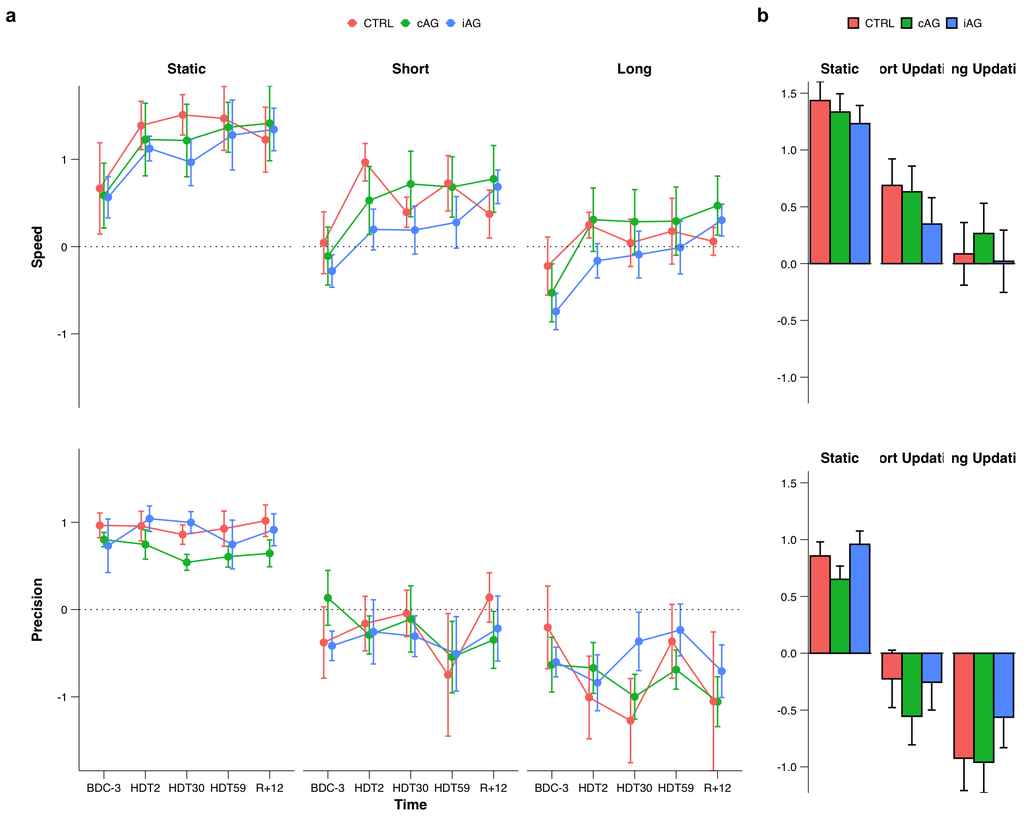

# 3 Point to Origin Task

## 3.1 Show Time Course adjusted for Baseline

```r
# Plot arithmetic means

# Pitch
# Compute desc
desc <- func_desc(df_pto, group_3, time.f, cond.f, axis, variable)

# Drop vars
desc <- subset(desc, variable != "rating_z" & variable != "direction_z" & variable != "eff_z")

desc <- subset(desc, axis == "Pitch")

# Plot desc
# New facet label names for variable
new_labels <- c("Speed","Precision", "Distance Est.")
names(new_labels) <- c("rt_z","variable_pointing_error_z", "dist_error_z")

new_labels2 <- c("1-Turn", "2-Turn", "3-Turn")
names(new_labels2) <- c("2", "3", "5")

new_labels3 <- c("")
names(new_labels3) <- c("Pitch")

# Define aes for func_plot
tmpaes_plot <- aes(x = time.f, y = MEAN,
                   group = group_3,
                   fill = group_3,
                   color = group_3)

tmpaes_errorbar <- aes(x = time.f,
                    ymin = MEAN-SE,
                    ymax = MEAN+SE)

# Define labels for func_plot_line_facet
labeller_def <- labeller(variable = new_labels,
                         cond.f = new_labels2,
                         axis = new_labels3)

facet_grid_def <- facet_grid(variable ~ cond.f + axis,
                             switch = "y",
                             labeller = labeller_def)

# Draw plot
pd <- position_dodge(0.3)
p.pto_desc <- func_plot_line_facet(desc %>%
                                     mutate(time.f = fct_relevel(time.f, "BDC-3", "HDT2", "HDT30", "HDT59", "R+12"),
                                            variable = fct_relevel(variable, "rt_z", "variable_pointing_error_z", "dist_error_z"),
                                            group_3 = fct_relevel(group_3, "CTRL", "cAG", "iAG")))

# Add zero line
p.pto_desc <- p.pto_desc + geom_hline(yintercept = 0, size = 0.3, linetype = "dotted")

# Adjust legend size
p.pto_desc_pitch <- p.pto_desc + theme(legend.key.size = unit(0.3, "cm"))

# Yaw
# Compute desc
desc <- func_desc(df_pto, group_3, time.f, cond.f, axis, variable)

# Drop vars
desc <- subset(desc, variable != "rating_z" & variable != "direction_z" & variable != "eff_z")

desc <- subset(desc, axis == "Yaw")

# Plot desc
# New facet label names for variable
new_labels <- c("Speed","Precision", "Distance Est.")
names(new_labels) <- c("rt_z","variable_pointing_error_z", "dist_error_z")

new_labels2 <- c("1-Turn", "2-Turn", "3-Turn")
names(new_labels2) <- c("2", "3", "5")

new_labels3 <- c("")
names(new_labels3) <- c("Yaw")

# Define aes for func_plot
tmpaes_plot <- aes(x = time.f, y = MEAN,
                   group = group_3,
                   fill = group_3,
                   color = group_3)

tmpaes_errorbar <- aes(x = time.f,
                    ymin = MEAN-SE,
                    ymax = MEAN+SE)

# Define labels for func_plot_line_facet
labeller_def <- labeller(variable = new_labels,
                         cond.f = new_labels2,
                         axis = new_labels3)

facet_grid_def <- facet_grid(variable ~ cond.f + axis,
                             switch = "y",
                             labeller = labeller_def)

# Draw plot
pd <- position_dodge(0.3)
p.pto_desc <- func_plot_line_facet(desc %>%
                                     mutate(time.f = fct_relevel(time.f, "BDC-3", "HDT2", "HDT30", "HDT59", "R+12"),
                                            variable = fct_relevel(variable, "rt_z", "variable_pointing_error_z", "dist_error_z"),
                                            group_3 = fct_relevel(group_3, "CTRL", "cAG", "iAG")))

# Add zero line
p.pto_desc <- p.pto_desc + geom_hline(yintercept = 0, size = 0.3, linetype = "dotted")

# Adjust legend size
p.pto_desc_yaw <- p.pto_desc + theme(legend.key.size = unit(0.3, "cm"))
```

## 3.2 Mixed Model Time x Group Interaction

```r
# Arrange dep vars by cond.f
df_tmp <- df_pto[c(1:4,6,8,9)]
df_tmp <- reshape2::melt(df_tmp, id.vars = c("id","time.f","axis", "cond.f") )
df_tmp <- reshape2::dcast(df_tmp, id + time.f + axis ~ variable + cond.f, value.var = "value" )

# Add baseline as cov
bdc <- "BDC-3"
df_tmp <-  func_bdc_cov(df_tmp)

# Select dep vars
dvList <- colnames(df_tmp[c(23:28,20:22)])

# Define model
model_mm <- paste0(" + sex"," + age", " + time.f",  " * group_3", " * axis" ,"+ (1|id)" )

# Run mixed models
tbl_mm_fac_aov <- sapply(func_mm_fac_with_bdc_adj_help(dvList), anova, simplify = FALSE, USE.NAMES = TRUE)

# ANOVA table
tbl_mm_fac_aov_df <- func_tbl_aov(dvList)

# Helper functions for parameter definition in mixed model tables, takes 'dvList'
Parameter_func <- function(dvList){
  rep(c(
    "Baseline",
    "Sex",
    "Age",
    "Time",
    "Group",
    "Axis (Pitch, Yaw)",
    "Time x Group",
    "Time x Turning Axis",
    "Group x Turning Axis",
    "Time x Group x Turning Axis"),
  length(dvList))
}

# Add variables
Parameter <- Parameter_func(dvList)
blanks <- rep("", length(Parameter) / length(dvList) - 1)
Variable <- c("Speed 1-Turn", blanks, "Speed 2-Turn", blanks, "Speed 3-Turn", blanks, "Precision 1-Turn", blanks, "Precision 2-Turn", blanks, "Precision 3-Turn", blanks, "Dist. Error 1-Turn", blanks, "Dist. Error 2-Turn", blanks, "Dist. Error 3-Turn", blanks)
tbl_mm_fac_aov_df_pto <- cbind(Variable, Parameter, tbl_mm_fac_aov_df[c(4:7)])
```

#### 3.2.0.1 Table 6. Mixed Model Summary for Point to Origin Task.

| Variable | Parameter | df1 | df2 | F | P |
| --- | --- | --- | --- | --- | --- |
| Speed 1-Turn | Baseline | 1 | 340.8 | 0.55 | 0.458 |
|  | Sex | 1 | 17.96 | 0.96 | 0.341 |
|  | Age | 1 | 19.22 | 2.27 | 0.148 |
|  | Time | 3 | 321.08 | 19.32 | 0 |
|  | Group | 2 | 17.93 | 1.43 | 0.266 |
|  | Axis (Pitch, Yaw) | 1 | 321.06 | 0.67 | 0.414 |
|  | Time x Group | 6 | 321.07 | 1.3 | 0.257 |
|  | Time x Turning Axis | 3 | 321.01 | 1.59 | 0.191 |
|  | Group x Turning Axis | 2 | 321.06 | 3.47 | 0.032 |
|  | Time x Group x Turning Axis | 6 | 321.01 | 2.18 | 0.045 |

[output cut: 80 more lines]

## 3.3 Contrasts for Comparing Groups at Each Time Point

```r
# Contrasts
# Define model for contrasts
model_emmeans <- ~ time.f * group_3 * axis

# Define contrasts
contrast_type <- "pairwise"
factors <- c( "time.f", "axis")

# Run contrasts
tbl_contr_emm_fac_df <- func_tbl_contr_emm_fac_with_bdc_adj(dvList)

# Create vars to make nice table
tmp_n_dvs <- length(levels(tbl_contr_emm_fac_df$Contrast)) *
  length(levels(tbl_contr_emm_fac_df$time.f)) * length(levels(tbl_contr_emm_fac_df$axis)) * 3 -1
tmp_n_cond <- length(levels(tbl_contr_emm_fac_df$Contrast)) *
  length(levels(tbl_contr_emm_fac_df$time.f)) * length(levels(tbl_contr_emm_fac_df$axis)) -1
tmp_n_time <- length(levels(tbl_contr_emm_fac_df$Contrast)) - 1


tbl_contr_emm_fac_df$Variable <- c("Speed", rep("", tmp_n_dvs),
                                   "Precision", rep("", tmp_n_dvs),
                                   "Distance Est.", rep("", tmp_n_dvs))

tbl_contr_emm_fac_df$Condition <- c("1-Turn", rep("", tmp_n_cond),
                                          "2-Turn",rep("", tmp_n_cond),
                                          "3-Turn",rep("", tmp_n_cond))

tbl_contr_emm_fac_df$Time <- rep ( c("HDT2", rep("", tmp_n_time),
                                     "HDT30", rep("", tmp_n_time),
                                     "HDT59", rep("", tmp_n_time),
                                     "R+12", rep("", tmp_n_time)),
                                   length(dvList) )

tbl_contr_emm_fac_df_pto <- tbl_contr_emm_fac_df[c(9:11, 2, 8, 5:7)]
```

#### 3.3.0.1 Table 7. Mixed Model Group Contrasts for Point to Origin Task.

| Variable | Condition | Time | Contrast | Mean (95%CI) | df | t | P (unadjusted) |
| --- | --- | --- | --- | --- | --- | --- | --- |
| Speed | 1-Turn | HDT2 | cAG - CTRL | -1.03 (-1.85, -0.22) | 25.1 | -2.6 | 0.015 |
|  |  |  | cAG - iAG | -0.27 (-1.08, 0.54) | 25.4 | -0.69 | 0.498 |
|  |  |  | CTRL - iAG | 0.76 (-0.04, 1.57) | 24.3 | 1.95 | 0.063 |
|  |  | HDT30 | cAG - CTRL | -0.78 (-1.59, 0.04) | 24.4 | -1.97 | 0.06 |
|  |  |  | cAG - iAG | -0.46 (-1.26, 0.35) | 24.6 | -1.17 | 0.253 |
|  |  |  | CTRL - iAG | 0.32 (-0.49, 1.12) | 24.3 | 0.82 | 0.423 |
|  |  | HDT59 | cAG - CTRL | -0.55 (-1.36, 0.26) | 24.4 | -1.4 | 0.175 |
|  |  |  | cAG - iAG | -0.44 (-1.25, 0.37) | 25.2 | -1.13 | 0.27 |
|  |  |  | CTRL - iAG | 0.11 (-0.7, 0.92) | 24.9 | 0.27 | 0.79 |
|  |  | R+12 | cAG - CTRL | -0.53 (-1.34, 0.29) | 25.1 | -1.33 | 0.197 |

[output cut: 206 more lines]

## 3.4 Plot Estimated Marignal Means To Show Time Course for Each Group

```r
# Define model for emmeans
model_emmeans <- ~ time.f * group_3 * axis

# Run emmeans
emm_fac <- func_emm_fac_with_bdc_adj(dvList)

# Plot emmeans
# New facet label names for variable
new_labels <- c("Speed 1-Turn","Speed 2-Turn", "Speed 3-Turn",
                "Precision 1-Turn","Precision 2-Turn","Precision 3-Turn",
                "Distance Est. 1-Turn", "Distance Est. 2-Turn", "Distance Est. 3-Turn")
names(new_labels) <- c("rt_z_2", "rt_z_3", "rt_z_5",
                       "variable_pointing_error_z_2","variable_pointing_error_z_3",
                       "variable_pointing_error_z_5",
                       "dist_error_z_2","dist_error_z_3","dist_error_z_5")

new_labels2 <- c("Pitch", "Yaw")
names(new_labels2) <- c("Pitch", "Yaw")

# Define aes for func_plot
tmpaes_plot <- aes(x = time.f, y = emmean,
                   group = group_3,
                   fill = group_3,
                   color = group_3)

tmpaes_errorbar <- aes(x = time.f,
                    ymin = emmean-SE,
                    ymax = emmean+SE)

# Define labels for func_plot_line_facet
labeller_def <- labeller(.id = new_labels,
                                   axis = new_labels2)

facet_grid_def <- facet_grid(.id ~ axis,
                             switch = "y",
                             labeller = labeller_def)

# Draw plot
pd <- position_dodge(0.3)
p.pto_emmeans <- func_plot_line_facet(emm_fac %>%
                                        mutate(time.f = fct_relevel(time.f, "HDT2", "HDT30", "HDT59", "R+12"),
                                               .id = fct_relevel(.id, "rt_z_2", "rt_z_3", "rt_z_5",
                       "variable_pointing_error_z_2","variable_pointing_error_z_3",
                       "variable_pointing_error_z_5",
                       "dist_error_z_2","dist_error_z_3","dist_error_z_5"),
                                               group_3 = fct_relevel(group_3, "CTRL", "cAG", "iAG")))

# Add zero line
p.pto_emmeans <- p.pto_emmeans + geom_hline(yintercept = 0, size = 0.3, linetype = "dotted")

# Adjust legend size
p.pto_emmeans <- p.pto_emmeans + theme(legend.key.size = unit(0.3, "cm"))
```

## 3.5 Mixed Model for Main Effect of Bed Rest (excluding BDC)

```r
# Drop recovery
df_tmp <- subset(df_tmp, time.f !="R+12") # Drop baseline
df_tmp <- droplevels(df_tmp)

# Select dep vars
dvList <- colnames(df_tmp[c(23:28,20:22)])

# Define model
model_mm <- paste0(" + sex"," + age", " + group_3", " * axis", " + (1|id)" )

# Run mixed models
tbl_mm_fac_aov <- sapply(func_mm_fac_with_bdc_adj_help(dvList), anova, simplify = FALSE, USE.NAMES = TRUE)

# ANOVA table
tbl_mm_fac_aov_df <- func_tbl_aov(dvList)

# Helper functions for parameter definition in mixed model tables, takes 'dvList'
Parameter_func <- function(dvList){
  rep(c(
  "Baseline",
  "Sex",
  "Age",
  "Group",
  "Turning Axis",
  "Group x Turning Axis"),
                 length(dvList))
}

# Add variables
Parameter <- Parameter_func(dvList)
blanks <- rep("", length(Parameter) / length(dvList) - 1)
Variable <- c("Speed 1-Turn", blanks, "Speed 2-Turn", blanks, "Speed 3-Turn", blanks, "Precision 1-Turn", blanks, "Precision 2-Turn", blanks, "Precision 3-Turn", blanks, "Dist. Error 1-Turn", blanks, "Dist. Error 2-Turn", blanks, "Dist. Error 3-Turn", blanks)
tbl_mm_fac_aov_df_pto_main <- cbind(Variable, Parameter, tbl_mm_fac_aov_df[c(4:7)])
```

#### 3.5.0.1 Table 8. Mixed Model Summary testing the Main Effect of Group for Point to Oriign Task.

| Variable | Parameter | df1 | df2 | F | P |
| --- | --- | --- | --- | --- | --- |
| Speed 1-Turn | Baseline | 1 | 263.83 | 0.89 | 0.346 |
|  | Sex | 1 | 17.55 | 0.76 | 0.394 |
|  | Age | 1 | 19.47 | 2 | 0.174 |
|  | Group | 2 | 17.5 | 1.68 | 0.216 |
|  | Turning Axis | 1 | 246.6 | 0.15 | 0.694 |
|  | Group x Turning Axis | 2 | 246.59 | 4.31 | 0.014 |
| Speed 2-Turn | Baseline | 1 | 266.31 | 0.56 | 0.456 |
|  | Sex | 1 | 17.65 | 0.17 | 0.686 |
|  | Age | 1 | 17.67 | 3.78 | 0.068 |
|  | Group | 2 | 17.65 | 1.48 | 0.255 |

[output cut: 44 more lines]

##Contrasts for Comparing Groups

```r
# Contrasts
# Define model for contrasts
model_emmeans <- ~ group_3 * axis

# Define contrasts
contrast_type <- "trt.vs.ctrl"
factors <- c("axis")

# Run contrasts
tbl_contr_emm_fac_df <- func_tbl_contr_emm_fac_with_bdc_adj(dvList)

# Create vars to make nice table
tmp_n_dvs <- length(levels(tbl_contr_emm_fac_df$Contrast)) * length(levels(tbl_contr_emm_fac_df$axis)) * 3 -1
tmp_n_cond <- length(levels(tbl_contr_emm_fac_df$Contrast)) * length(levels(tbl_contr_emm_fac_df$axis)) -1


tbl_contr_emm_fac_df$Variable <- c("Speed", rep("", tmp_n_dvs),
                                   "Precision", rep("", tmp_n_dvs),
                                   "Distance Est.", rep("", tmp_n_dvs))

tbl_contr_emm_fac_df$Condition <- c("1-Turn", rep("", tmp_n_cond),
                                          "2-Turn",rep("", tmp_n_cond),
                                          "3-Turn",rep("", tmp_n_cond))


# Table for contrasts
tbl_contr_emm_fac_pto_main <- tbl_contr_emm_fac_df[c(8:9, 2, 7,4:6)]
```

#### 3.5.0.2 Table 9. Mixed Model Contrasts Comparing Groups for Point to Oriign Task.

| Variable | Condition | Contrast | Mean (95%CI) | df | t | P (unadjusted) |
| --- | --- | --- | --- | --- | --- | --- |
| Speed | 1-Turn | CTRL - cAG | 0.78 (0.03, 1.53) | 19 | 2.18 | 0.042 |
|  |  | iAG - cAG | 0.36 (-0.38, 1.11) | 19.1 | 1.02 | 0.319 |
|  |  | CTRL - cAG | 0.46 (-0.29, 1.21) | 18.9 | 1.29 | 0.213 |
|  |  | iAG - cAG | -0.03 (-0.77, 0.71) | 19 | -0.09 | 0.929 |
|  | 2-Turn | CTRL - cAG | 0.5 (-0.34, 1.35) | 20.2 | 1.25 | 0.227 |
|  |  | iAG - cAG | -0.13 (-0.96, 0.71) | 20.1 | -0.32 | 0.751 |
|  |  | CTRL - cAG | 0.48 (-0.36, 1.33) | 20 | 1.2 | 0.243 |
|  |  | iAG - cAG | -0.16 (-0.99, 0.67) | 20.1 | -0.4 | 0.693 |
|  | 3-Turn | CTRL - cAG | 0.39 (-0.43, 1.21) | 19.7 | 1 | 0.329 |
|  |  | iAG - cAG | -0.31 (-1.12, 0.51) | 19.5 | -0.79 | 0.438 |

[output cut: 26 more lines]

## 3.6 Plot Estimated Marignal Means to Compare Groups

```r
# Pitch
# Run emmeans
emm_fac <- func_emm_fac_with_bdc_adj(dvList)
emm_fac <- subset(emm_fac, axis == "Pitch")

# New facet label names for variable
new_labels <- c("1-Turn","2-Turn", "3-Turn",
                "1-Turn","2-Turn","3-Turn",
                "1-Turn", "2-Turn", "3-Turn")
names(new_labels) <- c("rt_z_2", "rt_z_3", "rt_z_5",
                       "variable_pointing_error_z_2","variable_pointing_error_z_3",
                       "variable_pointing_error_z_5",
                       "dist_error_z_2","dist_error_z_3","dist_error_z_5")

new_labels2 <- c("")
names(new_labels2) <- c("Pitch")

# Define aes for func_plot
tmpaes_plot <- aes(x = contrast,
                   y = emmean,
                   group = group_3,
                   fill = group_3,
                   color = group_3)

tmpaes_errorbar <- aes(x = axis,
                    ymin = emmean-SE,
                    ymax = emmean+SE)

tmpaes_geombar <- aes(x = axis,
                    y = emmean,
                    fill=group_3)

# Define labels for func_plot_line_facet
labeller_def <- labeller(.id = new_labels,
                                   axis = new_labels2)

facet_grid_def <- facet_wrap(.id ~ axis,
                             #switch = "y",
                             #scales = "free",
                             labeller = labeller_def,
                             ncol = 3)

# Draw Plot
pd <- position_dodge(0.99)
p.pto_emmeans_main <- func_plot_bar_facet(emm_fac %>%
                                            mutate(.id = fct_relevel(.id, "rt_z_2", "rt_z_3", "rt_z_5",
                       "variable_pointing_error_z_2","variable_pointing_error_z_3",
                       "variable_pointing_error_z_5",
                       "dist_error_z_2","dist_error_z_3","dist_error_z_5"),
                                               group_3 = fct_relevel(group_3, "CTRL", "cAG", "iAG")))


# Adjust legend size
p.pto_emmeans_main_pitch <- p.pto_emmeans_main + theme(legend.key.size = unit(0.3, "cm"))

# Yaw
# Run emmeans
emm_fac <- func_emm_fac_with_bdc_adj(dvList)
emm_fac <- subset(emm_fac, axis == "Yaw")

# New facet label names for variable
new_labels <- c("1-Turn","2-Turn", "3-Turn",
                "1-Turn","2-Turn","3-Turn",
                "1-Turn", "2-Turn", "3-Turn")
names(new_labels) <- c("rt_z_2", "rt_z_3", "rt_z_5",
                       "variable_pointing_error_z_2","variable_pointing_error_z_3",
                       "variable_pointing_error_z_5",
                       "dist_error_z_2","dist_error_z_3","dist_error_z_5")

new_labels2 <- c("")
names(new_labels2) <- c("Yaw")

# Define aes for func_plot
tmpaes_plot <- aes(x = contrast,
                   y = emmean,
                   group = group_3,
                   fill = group_3,
                   color = group_3)

tmpaes_errorbar <- aes(x = axis,
                    ymin = emmean-SE,
                    ymax = emmean+SE)

tmpaes_geombar <- aes(x = axis,
                    y = emmean,
                    fill=group_3)

# Define labels for func_plot_line_facet
labeller_def <- labeller(.id = new_labels,
                                   axis = new_labels2)

facet_grid_def <- facet_wrap(axis ~ .id ,
                             #switch = "y",
                             #scales = "free",
                             labeller = labeller_def,
                             ncol = 3)

# Draw Plot
pd <- position_dodge(0.99)
p.pto_emmeans_main <- func_plot_bar_facet(emm_fac %>%
                                            mutate(.id = fct_relevel(.id, "rt_z_2", "rt_z_3", "rt_z_5",
                       "variable_pointing_error_z_2","variable_pointing_error_z_3",
                       "variable_pointing_error_z_5",
                       "dist_error_z_2","dist_error_z_3","dist_error_z_5"),
                                               group_3 = fct_relevel(group_3, "CTRL", "cAG", "iAG")))


# Adjust legend size
p.pto_emmeans_main_yaw <- p.pto_emmeans_main + theme(legend.key.size = unit(0.3, "cm"))
```

### 3.6.1 Plot Combined plot

```r
# Combine plot Pitch
p.pto_comb_pitch <- plot_grid(p.pto_desc_pitch, p.pto_emmeans_main_pitch + rremove("x.text") + theme( strip.text.y = element_blank() ),
          labels = c("a", "b"),
          ncol = 2, nrow = 1,
          rel_widths = c(2.2, 0.8))

# Adjust legend size
p.pto_comb_pitch <- p.pto_comb_pitch + theme(legend.key.size = unit(0.3, "cm"))

# Save plot as pdf
pdf("./Figures/Spatial Cognition 1/p.pto_comb_pitch.pdf",
    width = 30/2.54,
    height = 20/2.54,
    useDingbats = FALSE) #in cm
print(p.pto_comb_pitch)
dev.off()
```

```r
# Combine plot Yaw
p.pto_comb_yaw <- plot_grid(p.pto_desc_yaw, p.pto_emmeans_main_yaw + rremove("x.text") + theme( strip.text.y = element_blank() ),
          labels = c("a", "b"),
          ncol = 2, nrow = 1,
          rel_widths = c(2.2, 0.8))

# Adjust legend size
p.pto_comb_yaw <- p.pto_comb_yaw + theme(legend.key.size = unit(0.3, "cm"))

# Save plot as pdf
pdf("./Figures/Spatial Cognition 1/p.pto_comb_yaw.pdf",
    width = 30/2.54,
    height = 20/2.54,
    useDingbats = FALSE) #in cm
print(p.pto_comb_yaw)
dev.off()
```